# 第5回 利子と価格②：物価指数

経済データ入門

第5回

利子と価格②：物価指数

お金のものさしは、伸び縮みする

経済データ入門

第5回 — Topic01

物価指数と消費者物価指数

基準の年を 100 として、値段を測る

## 前回の振り返り

前回のポイント — 第4回「利子と価格①：金利計算」

Q: 金利の数を使うとき、何を確かめたか

- **利息は元金 × 利率**：100 万円 × 1% ＝ 1 万円
- **時点を添える**：金利は年でちがう。いつの値かを書いた
- **`$` で留める**：`$B$1` は列 B と行 1 を留める印

今日は値段の全体、物価。ある年を 100 と読み替えて測る

## この回の道のりと「物価」シート

1

物価指数

2

買い物かご

演習 5-1

野菜の数量

3

複合参照

演習 5-2

割る年の付け替え

4

名目と実質

演習 5-3

女の実質

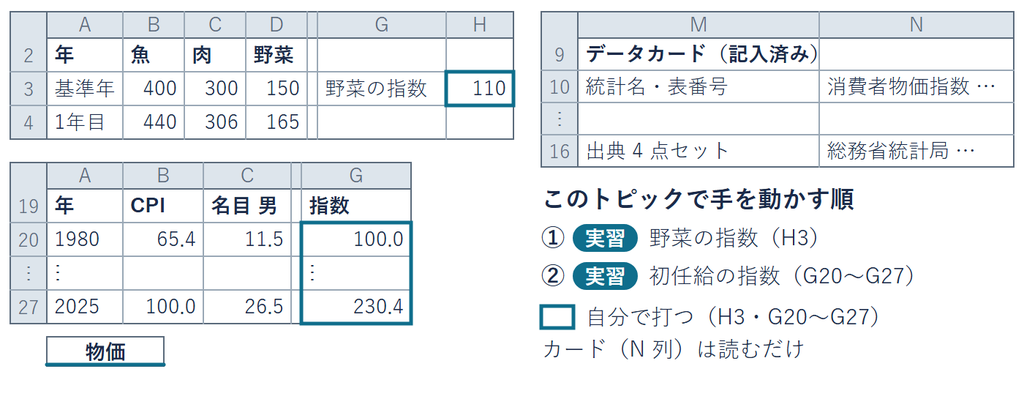

置き場は lec5-exercise.xlsx の「物価」シート。1 枚で回を通す

## たしかめ 初任給の伸びと豊かさ

大学卒の初任給（男）は 1980年に **11.5 万円**、2025年に **26.5 万円**  
金額は 2 倍以上。では、豊かさも 2 倍以上になったか

A

**2 倍以上、豊かになった**

B

**2 倍以上とは言えない**

- **出典**：厚生労働省「賃金構造基本統計調査」

1 つ決めてから先へ。答えは、この回の最後のトピックで出す

## 1 品目の値段の比べ方

[figure not shown]

- **サンプルデータ**：架空の値段（教科書 表10-2）
- **置き場**：lec5-exercise.xlsx「物価」の D3・D4

基準年の 150 円を 100 と置くと、1年目の 165 円は 110

## 物価指数と基準年

用語

**物価**：世の中の値段の全体の水準

**基準年**：値段を 100 と置く年

**物価指数**：基準年を 100 としたときの、比べる年の値段の位置

式

物価指数 ＝ 比べる年の値段 ÷ 基準年の値段 × 100

- **今回は**：165 ÷ 150 × 100 ＝ 110
- **第2回の指数**：値 ÷ 基準の値 × 100 と同じ形
- **読み方**：110 は、基準年より 1 割（10%）高い

## 失敗例 指数を円と読む誤り

110 を 110 円と読む  
「野菜は 110 円になった」  
値段は 165 円。110 は円ではない

基準年との比で読む  
「基準年を 100 とすると 110」  
1 割（10%）高い

- **なぜ起きるか**：値段に近い数なので、円に見える
- **確かめ方**：基準年の指数は、値段によらずいつも 100

## 1 品目の指数の式

1. **見る**：D3 の 150 と D4 の 165  
   （サンプルデータ・印刷済み）
2. **式**：H3 に `=D4/D3*100`  
   半角で打つ。`/` は「め」  
   `*` は Shift＋「け」

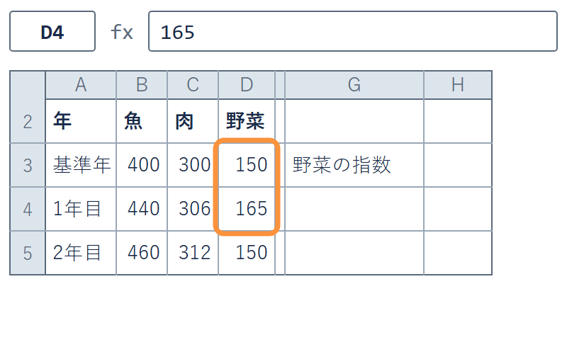

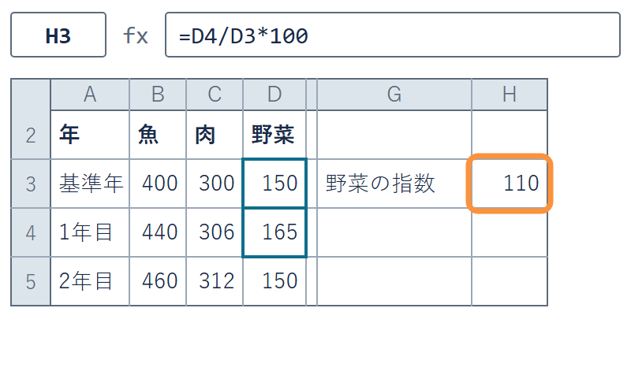

lec5-exercise.xlsx の H3。150 円を 100 と置くと、165 円は 110

✋ 動画を止めて STEP 1・2 を進め、H3 が 110 なら再生に戻る

## 初任給の指数

[figure not shown]

- **出典**：厚生労働省「賃金構造基本統計調査」（男）

1980 年を 100 として、26.5 ÷ 11.5 × 100 ＝ 230.4

## 初任給の指数の式

1. **式**：G20 に `=C20/$C$20*100`  
   `$C$20` で 1980 年に留める  
   （`$` は Shift＋4）
2. **引く**：G20 のフィルハンドルを  
   G27 までドラッグ
3. **見る**：G27 が 230.4  
   （小数 1 桁の書式つき）

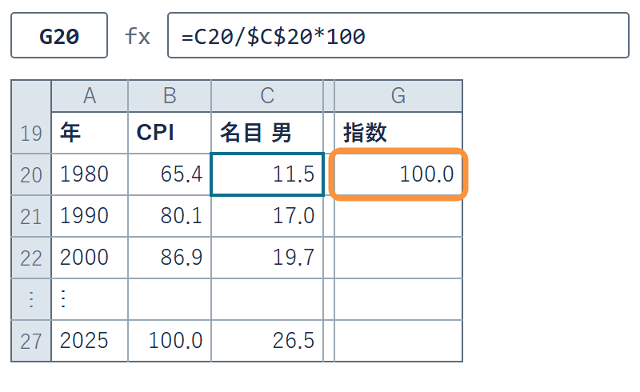

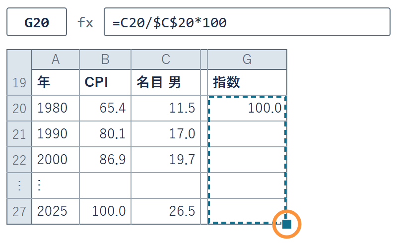

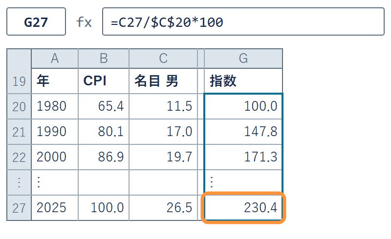

割る相手は 1980 年の C20 のまま。100.0・147.8・…・230.4 と並ぶ

✋ 動画を止めて STEP 1〜3 を進め、G27 が 230.4 なら再生に戻る

## 消費者物価指数

用語

**消費者物価指数**：値段の全体の物価指数（CPI）

**加工統計**：ほかの調査の結果から作る統計

- **作成機関**：総務省統計局。毎月公表する
- **基準年**：いまは 2025年を 100 とする
- **作り方**：小売物価統計調査と家計調査から計算
- **系列**：「総合」（全部の品目）と「生鮮食品を除く総合」など

ニュースの「物価が前年より◯%上がった」は、ほぼこの統計

## 消費者物価指数のものさし

[figure not shown]

- **出典**：総務省統計局「消費者物価指数」の総合

2025年＝100 とすると、1980 年は 65.4

## 消費者物価指数のデータカード

| 欄 | 消費者物価指数のカード（記入済み） |
| --- | --- |
| 統計名・表番号 | 消費者物価指数 全国 総合 年平均 （長期時系列データ・2025年基準） |
| 作成機関 | 総務省統計局 |
| 調査の種類 | **加工統計**（小売物価統計調査と家計調査から計算）・毎月 |
| 単位・基準 | **指数（2025年＝100）**・589 品目。円ではない |
| 定義の落とし穴 | 系列が複数ある・基準の年は 5 年ごとに変わる |
| 入手先・取得日 | 配布 PDF・**2026年10月8日** lecture05_消費者物価指数_総務省統計局_2025年平均.pdf |
| 出典 4 点セット | 総務省統計局「消費者物価指数（2025年基準）」 全国 総合 年平均、2026年10月8日取得 |

欄は第4回までと同じ 7 つ。ブックの N10〜N16 に記入済み

## まとめ

- **物価指数**：基準の年の値段を 100 と置く
- **今回は**：野菜 150 円 → 165 円で 110
- **初任給**：1980 年＝100 で 2025 年は 230.4
- **最初の問い**：初任給と物価の 2 つの指数が材料
- **CPI**：総務省統計局の加工統計（2025年＝100）

次は、たくさんの品目の値段を 1 つの指数にまとめる

経済データ入門

第5回 — Topic02

買い物かごとウェイト

全体の動きを 1 つの数にまとめる

## この回の道のりと「物価」シート

1

物価指数

2

買い物かご

演習 5-1

野菜の数量

3

複合参照

演習 5-2

割る年の付け替え

4

名目と実質

演習 5-3

女の実質

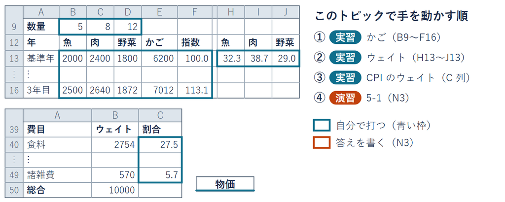

同じ「物価」シートの 9〜16 行目と 38〜50 行目に作る

## たしかめ かご全体の上がり方

3 年で、魚は 25%・肉は 10%・野菜は 4% 上がった  
魚 5・肉 8・野菜 12 のかご全体では、何% 上がるか

A

**25% 以上**

B

**10〜20%**

C

**ほぼ 0%**

- **値段**：魚 400 → 500 円・肉 300 → 330 円・野菜 150 → 156 円
- **サンプルデータ**：架空の値段と数量（教科書 表10-2）
- **置き場**：lec5-exercise.xlsx「物価」の B3:D6

1 つ決めてから先へ。答えは次のページで出す

## 3 品目のかごの金額

[figure not shown]

- **サンプルデータ**：架空の値段と数量（表10-2）
- **置き場**：lec5-exercise.xlsx「物価」の B3:D6

基準年は 6,200 円、3年目は 7,012 円。指数は 113.1

## 買い物かごと物価指数

用語

**買い物かご**：決まった品目と数量の組。その金額で物価を測る

**数量の固定**：数量は基準年のまま。どの年も同じ数量で買う

式

かごの物価指数 ＝  
比べる年のかごの金額 ÷ 基準年のかごの金額 × 100

- **今回は**：7,012 ÷ 6,200 × 100 ＝ 113.1
- **読み方**：かご全体は 13.1% 高い。前のページの答えは B
- **なぜ固定**：値段のせいか、買い方のせいかを分けるため

## ラスパイレス式

記号

$p$・$q$：値段・数量。添字の 0 は基準年、1 は比べる年

Σ（シグマ）：品目の数だけ足す記号

式

ラスパイレス式：物価指数 ＝ $\dfrac{\sum p_1 q_0}{\sum p_0 q_0} \times 100$

- **今回の分子**：500 × 5 ＋ 330 × 8 ＋ 156 × 12 ＝ 7,012 円（分母は 6,200 円）
- **分子の意味**：比べる年の値段で、基準年のかごを買う金額
- **パーシェ式**：比べる年の数量で固定する式。この回は使わない

## 失敗例 数量を式に書き込む誤り

数量を式に書き込む

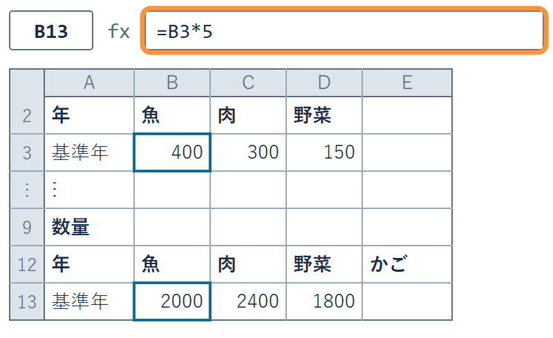

数量を変えると、式を打ち直す

数量をセルに置く

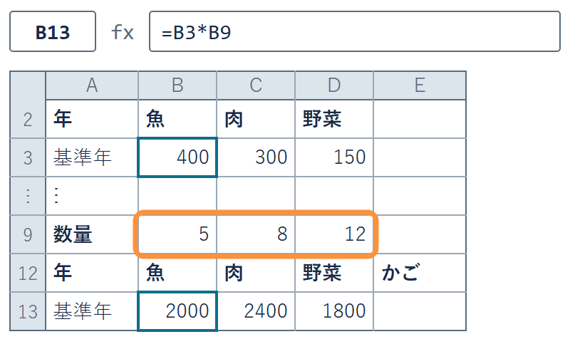

数量を変えても、式はそのまま

- **第4回の前提セル**：変えたい数は、式の外のセルに置く

## かごの金額の式

1. **数量**：B9・C9・D9 に  
   5・8・12 を打つ
2. **式**：B13 に `=B3*B9`  
   D13 まで右へフィル
3. **残り 3 行**：B14 に `=B4*B9`  
   B15・B16 も同じ形で打ち、右へ

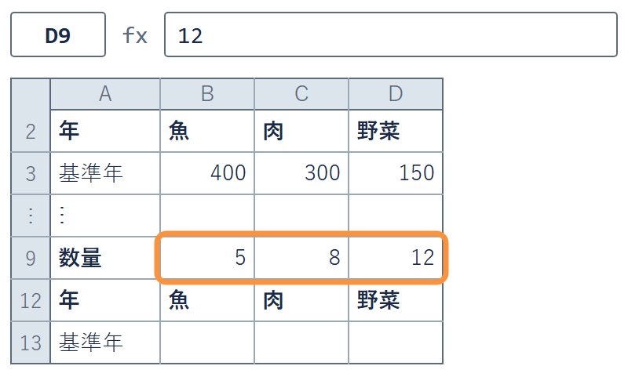

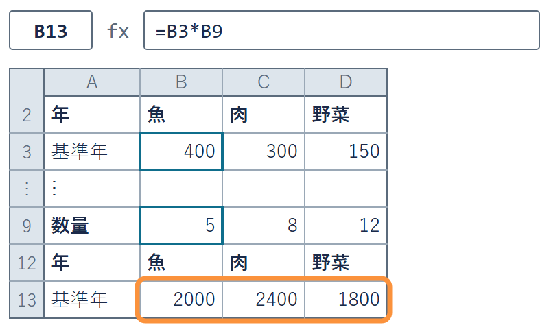

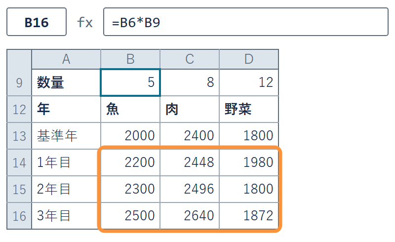

13 行目は 2000・2400・1800. 4 本とも打って、D16 が 1872

✋ 動画を止めて STEP 1〜3 を進め、D16 が 1872 なら再生に戻る

## かごの物価指数の式

1. **合計**：E13 に `=SUM(B13:D13)`  
   E16 まで下へフィル
2. **指数**：F13 に `=E13/$E$13*100`  
   F16 まで下へフィル
3. **見る**：F16 が 113.1  
   （小数 1 桁の書式つき）

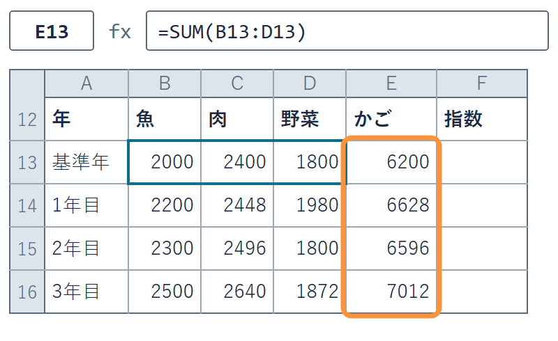

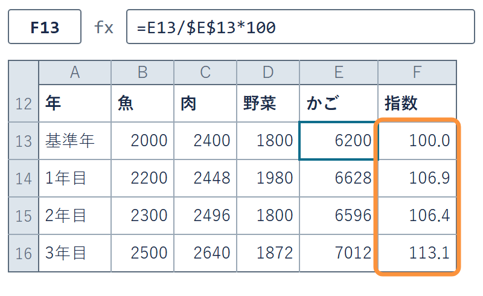

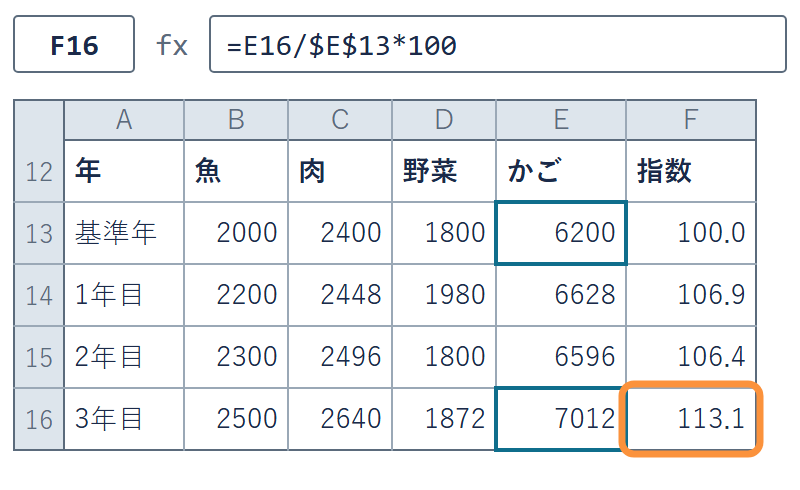

100.0・106.9・106.4・113.1。2年目は野菜が下がり、1年目より低い

✋ 動画を止めて STEP 1〜3 を進め、F16 が 113.1 なら再生に戻る

## かごの中身の割合

[figure not shown]

- **サンプルデータ**：lec5-exercise.xlsx の B13:E13

基準年のかご 6,200 円のうち、魚は 2,000 円で 32.3%

## ウェイト

用語

**ウェイト**：基準年のかごの金額のうち、品目が占める割合

式

ウェイト ＝ 品目の金額 ÷ かごの金額 × 100（%）

- **今回は**：魚 2,000 ÷ 6,200 × 100 ＝ 32.3（%）
- **肉と野菜**：38.7% と 29.0%。3 つ足すと 100%
- **読み方**：ウェイトの大きい品目ほど、かごの金額を大きく動かす

## ウェイトの式

1. **式**：H13 に `=B13/$E$13*100`  
   `$E$13` で基準年のかごに留める
2. **引く**：H13 のフィルハンドルを  
   J13 まで右へドラッグ
3. **見る**：J13 が 29.0  
   （H13 は 32.3・I13 は 38.7）

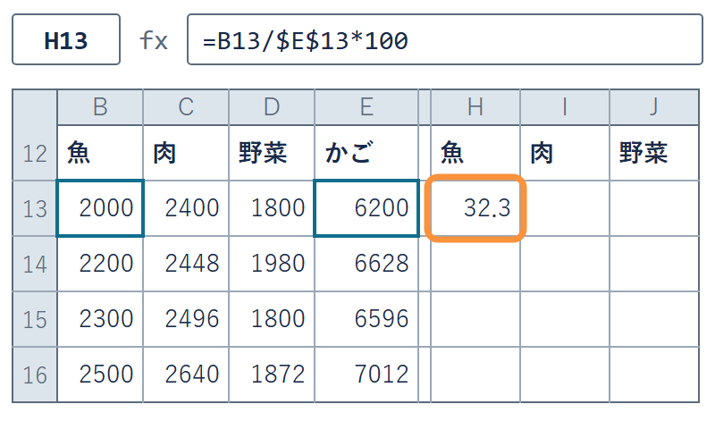

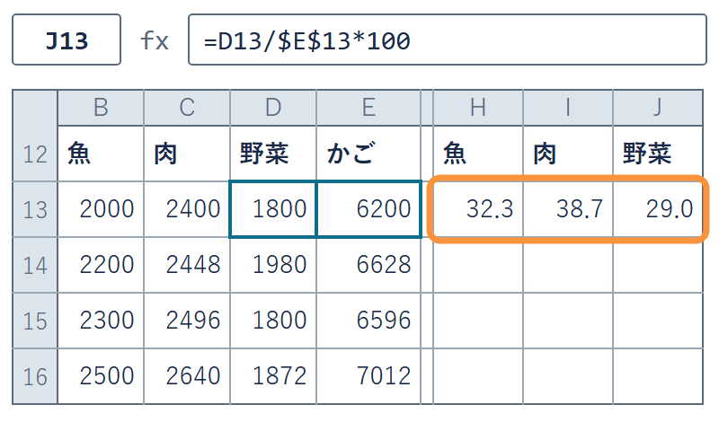

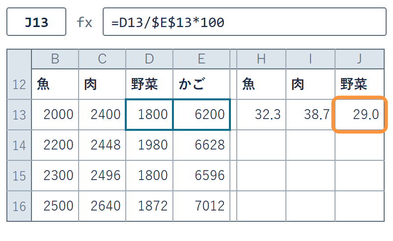

割る相手は E13 のまま。3 つ足すと 100.0

✋ 動画を止めて STEP 1〜3 を進め、J13 が 29.0 なら再生に戻る

## 品目の指数とウェイト

[figure not shown]

- **品目の指数**：3年目 ÷ 基準年 × 100（サンプルデータ）
- **ならす**：125 × 0.323 ＋ 110 × 0.387 ＋ 104 × 0.290 ≈ 113.1

品目の指数を、ウェイトで重みをつけて平均しても 113.1

## 穀類と総合の上がり方

穀類（米・パンなど）

82.0 → 100.0  
**1 年で 22.0% 上がった**

総合（値段の全体）

96.9 → 100.0  
**1 年で 3.2% 上がった**

- **出典**：総務省統計局「消費者物価指数」  
  品目別 2024・2025年（2025年＝100）
- **上がり方**：（100.0 − 82.0）÷ 82.0 × 100 ≈ 22.0%（第2回の増減率）
- **穀類の重さ**：全体を 10000 とすると 252（2.5%）。同じ表から

1 品目が 22% 上がっても、全体は 3.2%。全体はかごで測る

## 消費者物価指数のウェイト

[figure not shown]

- **出典**：総務省統計局「消費者物価指数」2025年基準
- **元の調査**：第3回の家計調査

CPI のかごの中身。食料 27.5%・住居 21.8%・交通・通信 14.4%

## 消費者物価指数のウェイトの式

1. **見る**：A40〜A49 が 10 の費目  
   B50 が総合の 10000（印刷済み）
2. **式**：C40 に `=B40/$B$50*100`  
   C49 まで下へフィル
3. **見る**：C40 が 27.5  
   （食料のウェイトの割合）

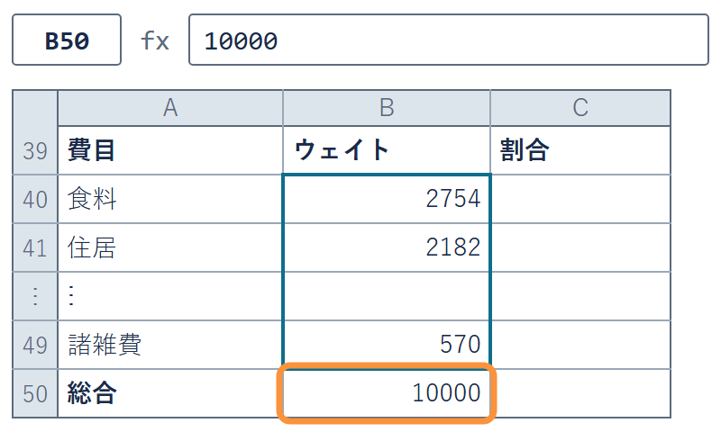

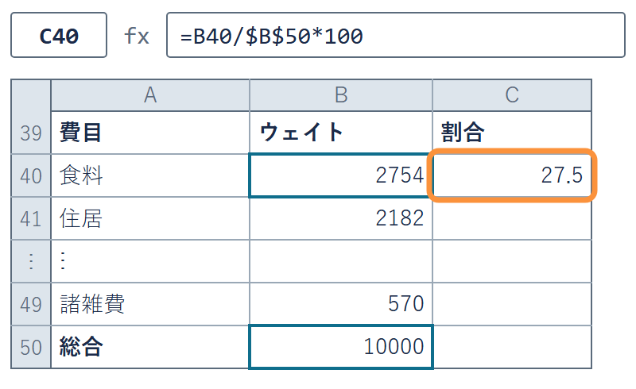

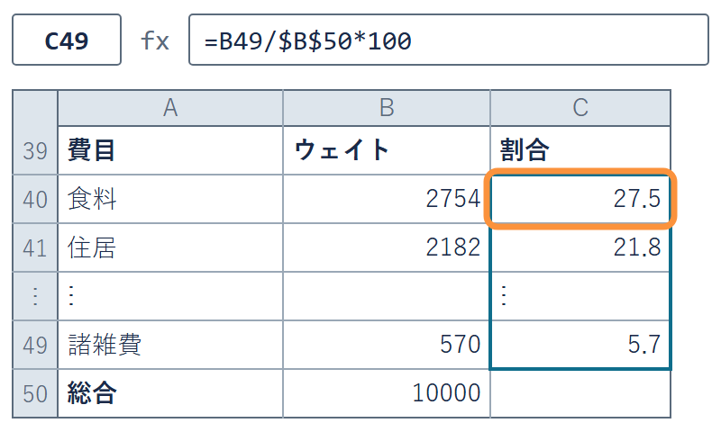

1 万分比を % に直した。割る相手は B50 の総合のまま

✋ 動画を止めて STEP 1〜3 を進め、C40 が 27.5 なら再生に戻る

## 演習 5-1 野菜の数量と物価指数

演習 5-1

野菜の数量を 15 にすると、3年目の物価指数はいくつか

1. **変える**：D9 の 12 を 15 にする（式は直さない）
2. **書く**：F16 の数を、N3 に値で打つ
3. **戻す**：D9 を 12 に戻し、F16 が 113.1 に戻るのを見る

たしかめ：113.1 から上がったか、下がったか。J13 も見る

✋ 動画を止めて 3 分。N3 に打ち、D9 を戻したら再生に戻る

## 演習 5-1 の答えの例

| セル | D9 が 12（元） | D9 が 15 |
| --- | --- | --- |
| E13 基準年のかご | 6200 | 6650 |
| E16 3年目のかご | 7012 | 7480 |
| F16 物価指数 | 113.1 | **112.5** |
| J13 野菜のウェイト | 29.0 | **33.8** |

- **N3**：112.5 を打ち、D9 を 12 に戻す
- **なぜ下がるか**：上がり方の小さい野菜（4%）が重くなった

## まとめ

- **買い物かご**：数量を基準年で固定したかごの金額で測る
- **今回は**：7,012 ÷ 6,200 × 100 ＝ 113.1
- **ウェイト**：かごの金額に占める割合。魚 32.3%・肉 38.7%・野菜 29.0%
- **CPI**：食料 27.5%・住居 21.8%・交通・通信 14.4% のかご

次は、4 本打ったかごの式を 1 本にまとめる

経済データ入門

第5回 — Topic03

複合参照と基準年の付け替え

どこを 100 にするかで、数字が変わる

## この回の道のりと「物価」シート

1

物価指数

2

買い物かご

演習 5-1

野菜の数量

3

複合参照

演習 5-2

割る年の付け替え

4

名目と実質

演習 5-3

女の実質

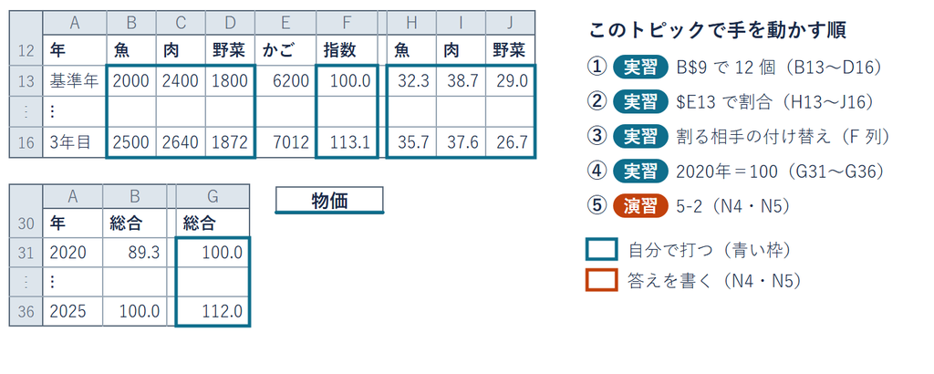

同じ「物価」シートの 13〜16 行目と G31〜G36 に作る

## たしかめ 1 本の式のフィル

前のトピックでは、かごの式を 4 本とも打った  
B13 の `=B3*B9` 1 本を B16 まで下へ引くと、どうなるか

A

**正しく並ぶ**

B

**全部 2000**

C

**壊れる**

- **サンプルデータ**：架空の値段と数量（教科書 表10-2）
- **置き場**：lec5-exercise.xlsx「物価」の B3:D6 と B9:D9

1 つ決めてから先へ。答えは次のページで出す

## 下へ引いたかごの式

[figure not shown]

- **サンプルデータ**：lec5-exercise.xlsx「物価」の B3:D6・B9:D9

B14 は `=B4*B10` で 0 になる。  
B16 は字の「魚」を掛けて #VALUE! になる。答えは C

## 右へ引いたかごの式

[figure not shown]

- **前に出てきた `$B$9`**：行も列も留める形（第4回）
- **サンプルデータ**：lec5-exercise.xlsx「物価」の B3:D6・B9:D9

`$B$9` で下は直る。  
右へ引くと C13 は 1500 になる。肉に魚の数量 5

## 複合参照

用語

**複合参照**：行だけ、または列だけを `$` で留める書き方

`B$9`：行の 9 だけ留める。列の B は動く

`$B9`：列の B だけ留める。行の 9 は動く

決め

フィルで動いてほしくない側に、`$` を付ける

- **前の `$B$1`**：列の `$B` と行の `$1` の 2 つ（第4回）。片方だけ付けてよい
- **今回は**：下へは 9 行目のまま、  
  右へは C・D と動いてほしい。だから `B$9`

## 複合参照の 12 個の式

[figure not shown]

- **C13 は `=C3*C$9`**：肉の値段 300 × 肉の数量 8 ＝ 2400
- **B16 は `=B6*B$9`**：3年目の魚の値段 500 × 魚の数量 5 ＝ 2500

右へ引くと、列の字だけ動く。  
下へ引くと、行の数だけ動く。9 はそのまま

## F4 キーによる切り替え

[figure not shown]

- **使い方**：数式バーで `B9` の字の上をクリックし、`F4` を押す
- **Mac**：`⌘ + T`。ノート PC は `Fn + F4` の機種もある

1 回で `$B$9`、2 回で `B$9`、3 回で `$B9`

## 複合参照のかごの式

1. **直す**：数式バーの `B9` で  
   `F4` を 2 回 → `=B3*B$9`
2. **右へ**：B13 を D13 まで  
   右へフィル
3. **下へ**：B13:D13 を選んだまま  
   D16 まで下へフィル

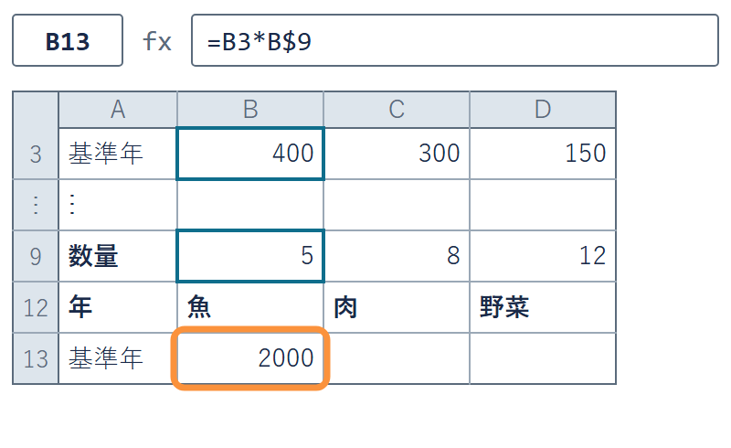

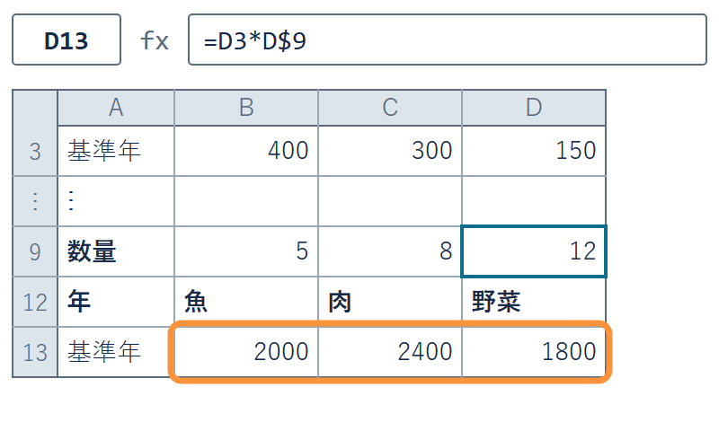

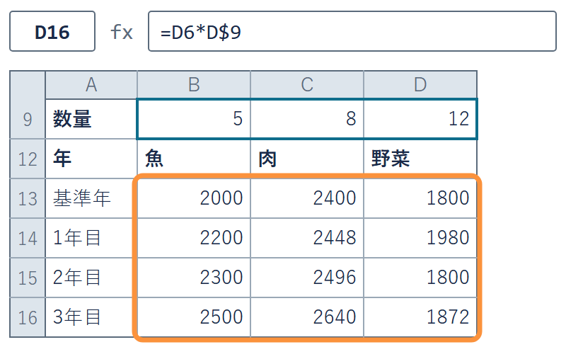

B16:D16 が 2500・2640・1872. 4 本打った表と同じ数

✋ 動画を止めて STEP 1〜3 を進め、B16 が 2500 なら再生に戻る

## 列だけ留める参照

[figure not shown]

- **各年の割合**：その年のかご（E 列）で割る
- **サンプルデータ**：lec5-exercise.xlsx「物価」の B13:E16

`$E$13` のまま下へ引くと H16 は 40.3 になる。`$E13` なら 35.7

## 各年の割合の式

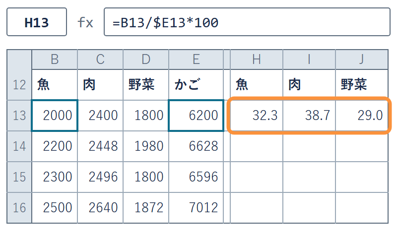

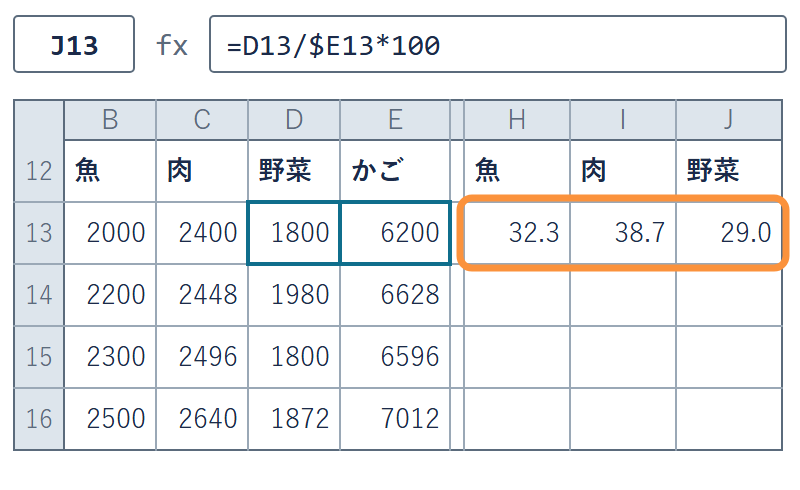

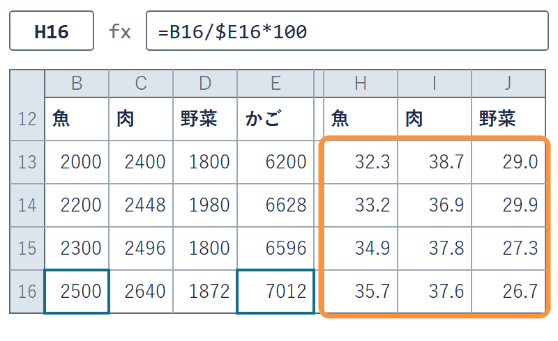

H16 が 35.7 になる。どの行も、3 つ足すと 100%

✋ 動画を止めて STEP 1〜3 を進め、H16 が 35.7 なら再生に戻る

## たしかめ 割る相手の付け替え

F13 の割る相手を、2年目のかご E15 に変える  
3年目の物価指数 F16（いまは 113.1）は、どうなるか

A

**上がる**

B

**下がる**

C

**変わらない**

- **式**：F13 を `=E13/$E$15*100` にして、F16 まで下へ
- **サンプルデータ**：値段の表 B3:D6 は 1 つも変えない  
  （lec5-exercise.xlsx「物価」）

1 つ決めてから先へ。答えは次のページで出す

## 割る相手と物価指数

[figure not shown]

100 の線を基準年に置くと 113.1 になる。  
2年目に置くと 106.3 になる。棒は動かない

## 基準の年と物価指数

| 年 | 基準年＝100 | 2年目＝100 |
| --- | --- | --- |
| 基準年 | 100.0 | 94.0 |
| 1年目 | 106.9 | 100.5 |
| 2年目 | 106.4 | 100.0 |
| 3年目 | 113.1 | **106.3** |

決め

指数は、どの年を 100 にしたかとセットでしか意味を持たない

- **変えたのは**：割る相手（E13 → E15）だけ。前のページの答えは B
- **サンプルデータ**：値段は 1 円も変えていない（lec5-exercise.xlsx「物価」）

## 割る相手の付け替えの式

1. **変える**：数式バーで `$E$13` を  
   `$E$15` にし、F16 まで下へ
2. **見る**：F16 が 106.3  
   （値段の表はそのまま）
3. **戻す**：F13 を `=E13/$E$13*100` に  
   戻し、F16 まで下へ

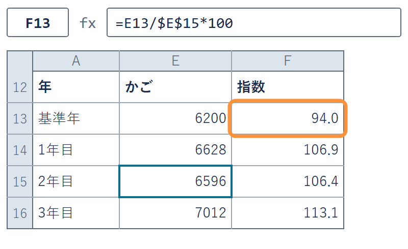

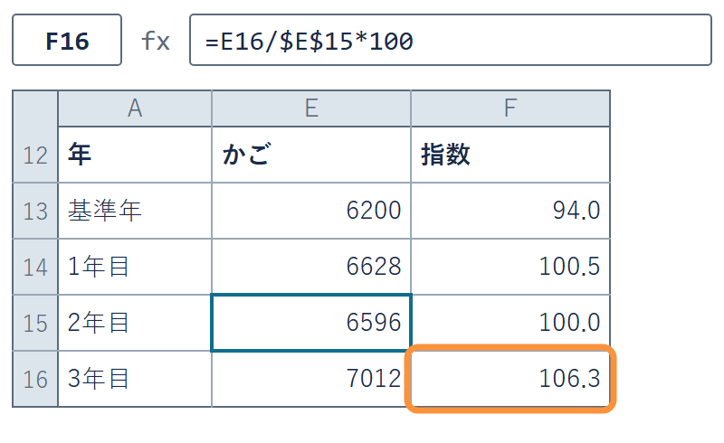

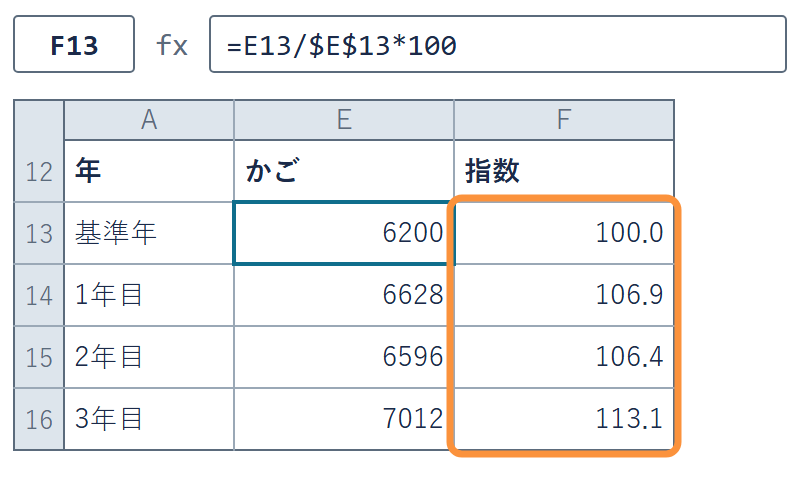

付け替えたら、13 行目に戻して元の表にする

✋ 動画を止めて STEP 1〜3 を進め、F16 が 113.1 に戻ったら再生に戻る

## 基準年改定

[figure not shown]

いまの CPI は 2025年が 100 で、2020年は 89.3 になる。  
2020年を 100 にすると、2025年は 112.0 になる